# Probability & Probability Distributions

# Formative Assessment 6

**Name:** CALALANG, JHAN CAZHANDRA D.

**Section:** APM1110 - SECTION 2

# Section I. Geometric Distribution

The geometric distribution models the number of trials required to achieved the first success in a sequence of Bernouli trials.

```r
p <- 0.2
```

```r
x <- rgeom(1000, prob = p) + 1
```

```r
mean_x <- mean(x)
var_x <- var(x)
sd_x <- sd(x)
```

```r
cat("Number of trials required to achieve first success:", x[1], "\n")
```

```
## Number of trials required to achieve first success: 9
```

```r
cat("Mean (in 2 decimal places):", sprintf("%.2f", mean_x), "\n")
```

```
## Mean (in 2 decimal places): 5.09
```

```r
cat("Variance (in 2 decimal places):", sprintf("%.2f", var_x), "\n")
```

```
## Variance (in 2 decimal places): 21.80
```

```r
cat("Standard deviation (in 2 decimal places):", sprintf("%.2f", sd_x), "\n")
```

```
## Standard deviation (in 2 decimal places): 4.67
```

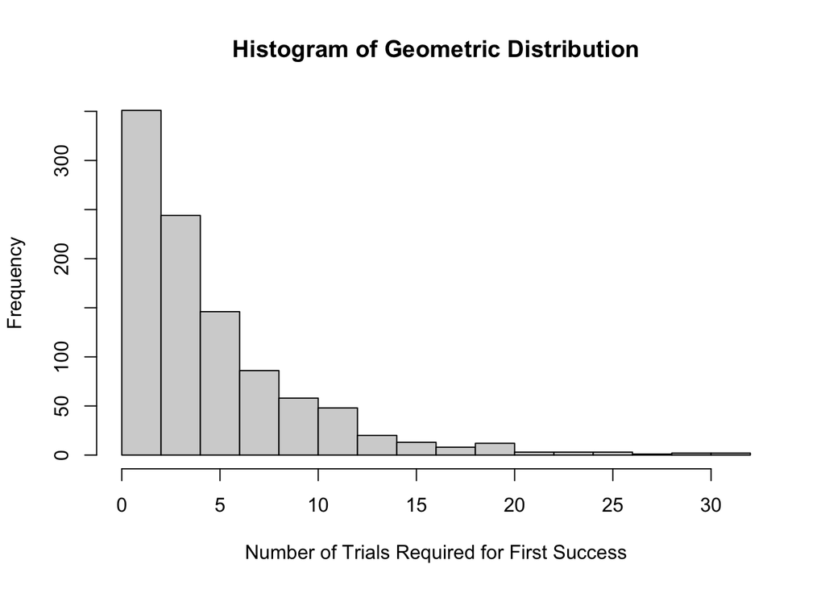

```r
hist(
  x,
  main = "Histogram of Geometric Distribution",
  xlab = "Number of Trials Required for First Success",
  ylab = "Frequency"
)
```

# Section II. Hypergeometric Distribution

The problem states that 10% of the IC chips are expected to be defective. A sample of 10 chips is selected, and the probability that the sample contains more than 10% defectives is estimated using the hypergeometric distribution.

## 1. A sample of 10 is selected from a box of 40

For a box of 40 chips, 10% of the chips are expected to be defective. Therefore, the number of defective chips is 4, and the sample size is 10.

```r
N1 <- 40
K1 <- 4
n1 <- 10
```

```r
prob_1 <- 1 - phyper(1, m = K1, n = N1 - K1, k = n1)

prob_1
```

```
## [1] 0.2558814
```

```r
cat("Probability of more than 10% defectives:", sprintf("%.4f", prob_1), "\n")
```

```
## Probability of more than 10% defectives: 0.2559
```

```r
cat("Percentage:", sprintf("%.2f%%", prob_1 * 100), "\n")
```

```
## Percentage: 25.59%
```

The probability represents the chance that a rancom sample of 10 chips from a box of 40 contains at least 2 defective chips, which is more than 10% of the sample.

## 2. A sample of 10 is selected from a box of 5000

For a box of 5000 chips, 10% of the chips are expected to be defective. Therefore, the number of defective chips is 500, and the sample size is 10.

```r
N2 <- 5000
K2 <- 500
n2 <- 10
```

```r
prob_2 <- 1 - phyper(1, m = K2, n = N2 - K2, k = n2)

prob_2
```

```
## [1] 0.2638622
```

```r
cat("Probability of more than 10% defectives:", sprintf("%.4f", prob_2), "\n")
```

```
## Probability of more than 10% defectives: 0.2639
```

```r
cat("Percentage:", sprintf("%.2f%%", prob_2 * 100), "\n")
```

```
## Percentage: 26.39%
```

The probability represents the chance that a random sample of 10 chips from a box of 5000 contains at least 2 defective chips, which is more than 10% of the sample.

# Summary of Hypergeometric Results

```r
data.frame(
  Case = c("10 chips from 40", "10 chips from 5000"),
  Probability = c(prob_1, prob_2),
  Percentage = c(prob_1 * 100, prob_2 * 100)
)
```

```
##                 Case Probability Percentage
## 1   10 chips from 40   0.2558814   25.58814
## 2 10 chips from 5000   0.2638622   26.38622
```